# Mineria de Datos I

Gerard Chicot Navalls

28/1/2023

```r
source("Funciones_R.R")
```

```r
getwd()
```

```
## [1] "C:/Users/xikix/Downloads/Mineria de datos 1"
```

```r
setwd("C:/Users/xikix/Downloads/Mineria de datos 1")
```

```r
datos <- readRDS("FugaClientes_Training.RDS")
df_test <- readRDS("FugaClientes_Test.RDS")
```

```r
library(DT)
library(questionr)
library(psych)
library(car)
library(corrplot)
library(ggplot2)
library(gridExtra)
library(kableExtra)
library(dplyr)
library(DMwR2)
library(pROC)
library(caret)
library(glmnet)
library(tinytex)
```

## 1) Lectura e inspección de datos. Tipo de variables, distribuciones, valores extraños, etc

```r
tibble(datos)
```

```
## # A tibble: 6,353 x 21
##    ID      Genero Mayor65 Conyuge PersCargo Antig.fc.edad Telf_serv VariasLineas
##    <fct>   <fct>  <fct>   <fct>   <fct>             <dbl> <fct>     <fct>
##  1 7590-V~ Female 0       Yes     No                    1 No        No
##  2 5575-G~ Male   0       No      No                   34 Yes       No
##  3 3668-Q~ Male   0       No      No                    2 Yes       No
##  4 7795-C~ <NA>   0       No      No                   45 No        No
##  5 9237-H~ Female 0       No      No                   NA Yes       No
##  6 9305-C~ Female 0       No      No                    8 Yes       Yes
##  7 1452-K~ Male   0       No      Yes                  22 Yes       Yes
##  8 6713-O~ Female 0       No      No                   10 No        No
##  9 7892-P~ <NA>   0       Yes     No                   28 Yes       Yes
## 10 6388-T~ Male   0       No      Yes                  62 Yes       No
## # ... with 6,343 more rows, and 13 more variables: Int_serv <fct>,
## #   Seguridad <fct>, CopiaSeguridad <fct>, Antivirus_disp <fct>,
## #   Soporte_tecnico <fct>, TV_streaming <fct>, Peliculas <fct>, Contrato <fct>,
## #   Fact_sinPapel <fct>, MetodoPago <fct>, FacturaMes <dbl>,
## #   FacturaTotal <dbl>, Fuga <fct>
```

```r
datatable(head(datos,1000), options = list(autoWidth = TRUE, scrollX = TRUE),
              caption = 'Datos Clientes',
              class = 'cell-border stripe nowrap')
```

|  | ID | Genero | Mayor65 | Conyuge | PersCargo | Antig.fc.edad | Telf_serv | VariasLineas | Int_serv | Seguridad | CopiaSeguridad | Antivirus_disp | Soporte_tecnico | TV_streaming | Peliculas | Contrato | Fact_sinPapel | MetodoPago | FacturaMes | FacturaTotal | Fuga |
| --- | --- | --- | --- | --- | --- | --- | --- | --- | --- | --- | --- | --- | --- | --- | --- | --- | --- | --- | --- | --- | --- |
| 1 | 7590-VHVEG | Female | 0 | Yes | No | 1 | No | No | DSL | No | Yes | No | No | No | No | Month-to-month | Yes |  |  | 29.85 | 0 |
| 2 | 5575-GNVDE | Male | 0 | No | No | 34 | Yes | No | DSL | Yes | No | Yes | No | No | No | One year | No | Mailed check |  | 1889.5 | 0 |
| 3 | 3668-QPYBK | Male | 0 | No | No | 2 | Yes | No | DSL | Yes | Yes | No | No | No | No | Month-to-month | Yes | Mailed check | 53.85 | 108.15 | 1 |
| 4 | 7795-CFOCW |  | 0 | No | No | 45 | No | No | DSL | Yes | No | Yes | Yes | No | No | One year | No |  | 42.3 | 1840.75 | 0 |
| 5 | 9237-HQITU | Female | 0 | No | No |  | Yes | No | Fiber optic | No | No | No | No | No | No | Month-to-month | Yes | Electronic check | 70.7 | 151.65 | 1 |
| 6 | 9305-CDSKC | Female | 0 | No | No | 8 | Yes | Yes | Fiber optic | No | No | Yes | No | Yes | Yes | Month-to-month | Yes |  | 99.65 | 820.5 | 1 |
| 7 | 1452-KIOVK | Male | 0 | No | Yes | 22 | Yes | Yes | Fiber optic | No | Yes | No | No | Yes | No | Month-to-month | Yes | Credit card (automatic) |  | 1949.4 | 0 |
| 8 | 6713-OKOMC | Female | 0 | No | No | 10 | No | No |  | Yes | No | No | No | No | No | Month-to-month | No | Mailed check | 29.75 | 301.9 | 0 |
| 9 | 7892-POOKP |  | 0 | Yes | No | 28 | Yes | Yes | Fiber optic | No | No | Yes | Yes | Yes | Yes | Month-to-month | Yes | Electronic check | 104.8 | 3046.05 | 1 |
| 10 | 6388-TABGU | Male | 0 | No | Yes | 62 | Yes | No | DSL | Yes | Yes | No | No | No | No |  | No |  | 56.15 | 3487.95 | 0 |

[output cut: 990 more lines]

- Podemos observar como el tamaño del archivo es de 6353 y 21 columnas.
- Las filas aportan información relacionada con usuarios de una compañia telefónica. Tenemos información sobre los usuarios y también sobre sus contrataciones pertinentes.

```r
str(datos)
```

```
## 'data.frame':    6353 obs. of  21 variables:
##  $ ID             : Factor w/ 6353 levels "0002-ORFBO","0003-MKNFE",..: 4858 3587 2338 4997 5879 5915 911 4316 5063 4102 ...
##  $ Genero         : Factor w/ 2 levels "Female","Male": 1 2 2 NA 1 1 2 1 NA 2 ...
##  $ Mayor65        : Factor w/ 2 levels "0","1": 1 1 1 1 1 1 1 1 1 1 ...
##  $ Conyuge        : Factor w/ 2 levels "No","Yes": 2 1 1 1 1 1 1 1 2 1 ...
##  $ PersCargo      : Factor w/ 2 levels "No","Yes": 1 1 1 1 1 1 2 1 1 2 ...
##  $ Antig.fc.edad  : num  1 34 2 45 NA 8 22 10 28 62 ...
##  $ Telf_serv      : Factor w/ 2 levels "No","Yes": 1 2 2 1 2 2 2 1 2 2 ...
##  $ VariasLineas   : Factor w/ 2 levels "No","Yes": 1 1 1 1 1 2 2 1 2 1 ...
##  $ Int_serv       : Factor w/ 3 levels "DSL","Fiber optic",..: 1 1 1 1 2 2 2 NA 2 1 ...
##  $ Seguridad      : Factor w/ 2 levels "No","Yes": 1 2 2 2 1 1 1 2 1 2 ...
##  $ CopiaSeguridad : Factor w/ 2 levels "No","Yes": 2 1 2 1 1 1 2 1 1 2 ...
##  $ Antivirus_disp : Factor w/ 2 levels "No","Yes": 1 2 1 2 1 2 1 1 2 1 ...
##  $ Soporte_tecnico: Factor w/ 2 levels "No","Yes": 1 1 1 2 1 1 1 1 2 1 ...
##  $ TV_streaming   : Factor w/ 2 levels "No","Yes": 1 1 1 1 1 2 2 1 2 1 ...
##  $ Peliculas      : Factor w/ 2 levels "No","Yes": 1 1 1 1 1 2 1 1 2 1 ...
##  $ Contrato       : Factor w/ 3 levels "Month-to-month",..: 1 2 1 2 1 1 1 1 1 NA ...
##  $ Fact_sinPapel  : Factor w/ 2 levels "No","Yes": 2 1 2 1 2 2 2 1 2 1 ...
##  $ MetodoPago     : Factor w/ 4 levels "Bank transfer (automatic)",..: NA 4 4 NA 3 NA 2 4 3 NA ...
##  $ FacturaMes     : num  NA NA 53.9 42.3 70.7 ...
##  $ FacturaTotal   : num  29.9 1889.5 108.2 1840.8 151.7 ...
##  $ Fuga           : Factor w/ 2 levels "0","1": 1 1 2 1 2 2 1 1 2 1 ...
```

Todas las variables tienen asignado el tipo correcto de datos, entre factor y número. También se puede observar los NA en distintas componentes.

```r
names(datos)
```

```
##  [1] "ID"              "Genero"          "Mayor65"         "Conyuge"
##  [5] "PersCargo"       "Antig.fc.edad"   "Telf_serv"       "VariasLineas"
##  [9] "Int_serv"        "Seguridad"       "CopiaSeguridad"  "Antivirus_disp"
## [13] "Soporte_tecnico" "TV_streaming"    "Peliculas"       "Contrato"
## [17] "Fact_sinPapel"   "MetodoPago"      "FacturaMes"      "FacturaTotal"
## [21] "Fuga"
```

```r
summary(datos)
```

```
##           ID          Genero     Mayor65     Conyuge    PersCargo
##  0002-ORFBO:   1   Female:2963   0   :5045   No :3287   No :4439
##  0003-MKNFE:   1   Male  :3038   1   : 956   Yes:3066   Yes:1914
##  0004-TLHLJ:   1   NA's  : 352   NA's: 352
##  0011-IGKFF:   1
##  0013-EXCHZ:   1
##  0013-MHZWF:   1
##  (Other)   :6347
##  Antig.fc.edad   Telf_serv   VariasLineas        Int_serv    Seguridad
##  Min.   : 0.00   No  : 605   No :3687     DSL        :2122   No :4532
##  1st Qu.: 9.00   Yes :5656   Yes:2666     Fiber optic:2702   Yes:1821
##  Median :29.00   NA's:  92                No         :1339
##  Mean   :32.38                            NA's       : 190
##  3rd Qu.:55.00
##  Max.   :72.00
##  NA's   :394
##  CopiaSeguridad Antivirus_disp Soporte_tecnico TV_streaming Peliculas
##  No :4180       No :4180       No :4509        No :3936     No :3902
##  Yes:2173       Yes:2173       Yes:1844        Yes:2417     Yes:2451
##
##
##
##
##
##            Contrato    Fact_sinPapel                     MetodoPago
##  Month-to-month:3285   No  :2483     Bank transfer (automatic):1283
##  One year      :1261   Yes :3609     Credit card (automatic)  :1290
##  Two year      :1413   NA's: 261     Electronic check         :1972
##  NA's          : 394                 Mailed check             :1336
##                                      NA's                     : 472
##
##
##    FacturaMes      FacturaTotal    Fuga
##  Min.   : 18.25   Min.   :  18.8   0:4667
##  1st Qu.: 35.55   1st Qu.: 394.5   1:1686
##  Median : 70.30   Median :1384.2
##  Mean   : 64.68   Mean   :2268.7
##  3rd Qu.: 89.80   3rd Qu.:3781.5
##  Max.   :118.75   Max.   :8672.5
##  NA's   :394      NA's   :11
```

```r
psych::describe(Filter(is.numeric, datos))
```

```
##               vars    n    mean      sd  median trimmed     mad   min     max
## Antig.fc.edad    1 5959   32.38   24.54   29.00   31.44   32.62  0.00   72.00
## FacturaMes       2 5959   64.68   30.01   70.30   64.87   35.58 18.25  118.75
## FacturaTotal     3 6342 2268.73 2258.84 1384.17 1954.72 1801.28 18.80 8672.45
##                 range  skew kurtosis    se
## Antig.fc.edad   72.00  0.24    -1.39  0.32
## FacturaMes     100.50 -0.22    -1.25  0.39
## FacturaTotal  8653.65  0.97    -0.22 28.36
```

```r
psych::describe(Filter(is.factor, datos))
```

```
##                  vars    n    mean      sd median trimmed     mad min  max
## ID*                 1 6353 3177.00 1834.10   3177 3177.00 2354.37   1 6353
## Genero*             2 6001    1.51    0.50      2    1.51    0.00   1    2
## Mayor65*            3 6001    1.16    0.37      1    1.07    0.00   1    2
## Conyuge*            4 6353    1.48    0.50      1    1.48    0.00   1    2
## PersCargo*          5 6353    1.30    0.46      1    1.25    0.00   1    2
## Telf_serv*          6 6261    1.90    0.30      2    2.00    0.00   1    2
## VariasLineas*       7 6353    1.42    0.49      1    1.40    0.00   1    2
## Int_serv*           8 6163    1.87    0.74      2    1.84    1.48   1    3
## Seguridad*          9 6353    1.29    0.45      1    1.23    0.00   1    2
## CopiaSeguridad*    10 6353    1.34    0.47      1    1.30    0.00   1    2
## Antivirus_disp*    11 6353    1.34    0.47      1    1.30    0.00   1    2
## Soporte_tecnico*   12 6353    1.29    0.45      1    1.24    0.00   1    2
## TV_streaming*      13 6353    1.38    0.49      1    1.35    0.00   1    2
## Peliculas*         14 6353    1.39    0.49      1    1.36    0.00   1    2
## Contrato*          15 5959    1.69    0.83      1    1.61    0.00   1    3
## Fact_sinPapel*     16 6092    1.59    0.49      2    1.62    0.00   1    2
## MetodoPago*        17 5881    2.57    1.07      3    2.59    1.48   1    4
## Fuga*              18 6353    1.27    0.44      1    1.21    0.00   1    2
##                  range  skew kurtosis    se
## ID*               6352  0.00    -1.20 23.01
## Genero*              1 -0.02    -2.00  0.01
## Mayor65*             1  1.86     1.47  0.00
## Conyuge*             1  0.07    -2.00  0.01
## PersCargo*           1  0.87    -1.25  0.01
## Telf_serv*           1 -2.73     5.45  0.00
## VariasLineas*        1  0.33    -1.89  0.01
## Int_serv*            2  0.21    -1.15  0.01
## Seguridad*           1  0.94    -1.11  0.01
## CopiaSeguridad*      1  0.67    -1.56  0.01
## Antivirus_disp*      1  0.67    -1.56  0.01
## Soporte_tecnico*     1  0.92    -1.15  0.01
## TV_streaming*        1  0.49    -1.76  0.01
## Peliculas*           1  0.47    -1.78  0.01
## Contrato*            2  0.64    -1.25  0.01
## Fact_sinPapel*       1 -0.38    -1.86  0.01
## MetodoPago*          3 -0.16    -1.21  0.01
## Fuga*                1  1.06    -0.87  0.01
```

```r
sapply(Filter(is.numeric, datos),function(x) length(unique(x)))
```

```
## Antig.fc.edad    FacturaMes  FacturaTotal
##            74          1523          5924
```

```r
listaHist <- dfplot_his(datos)
listaGraf <- dfplot_box(datos)
```

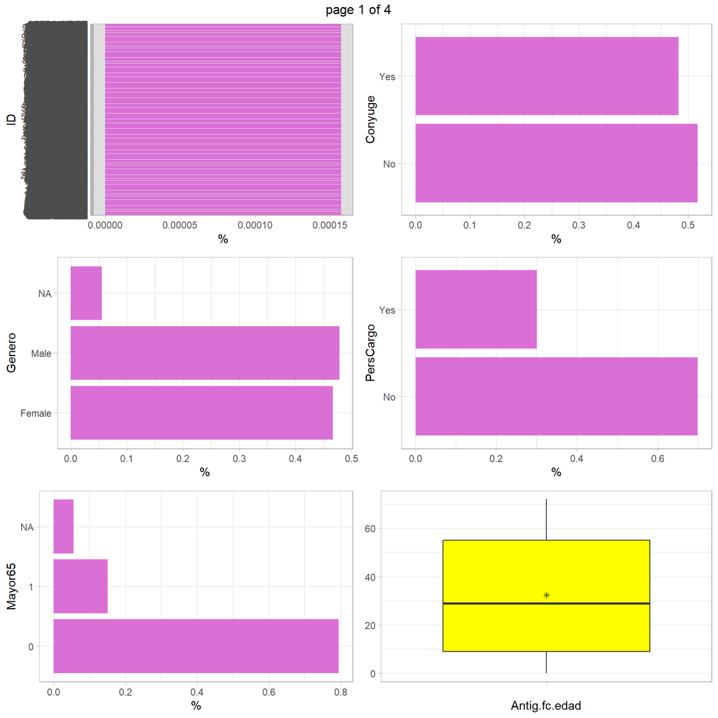

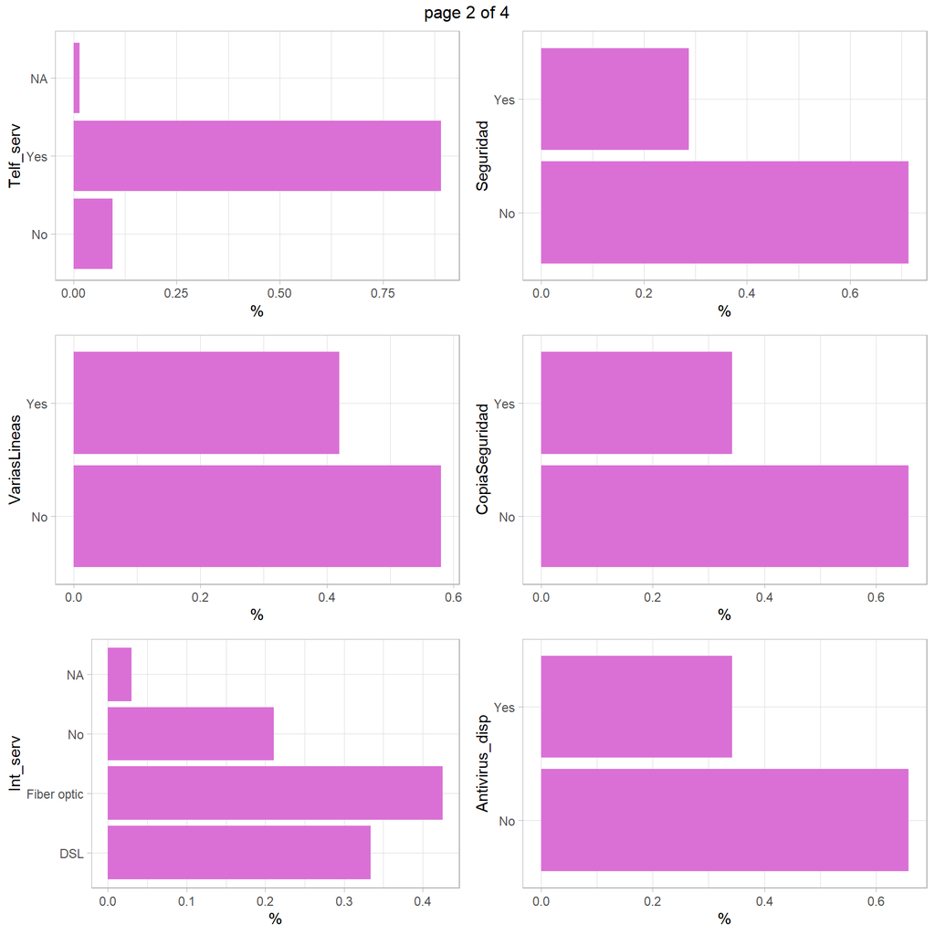

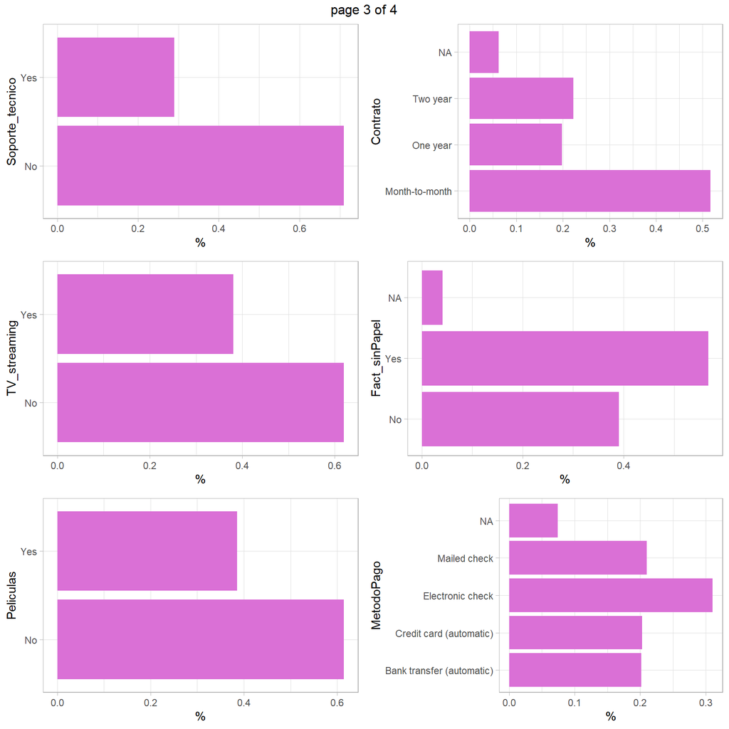

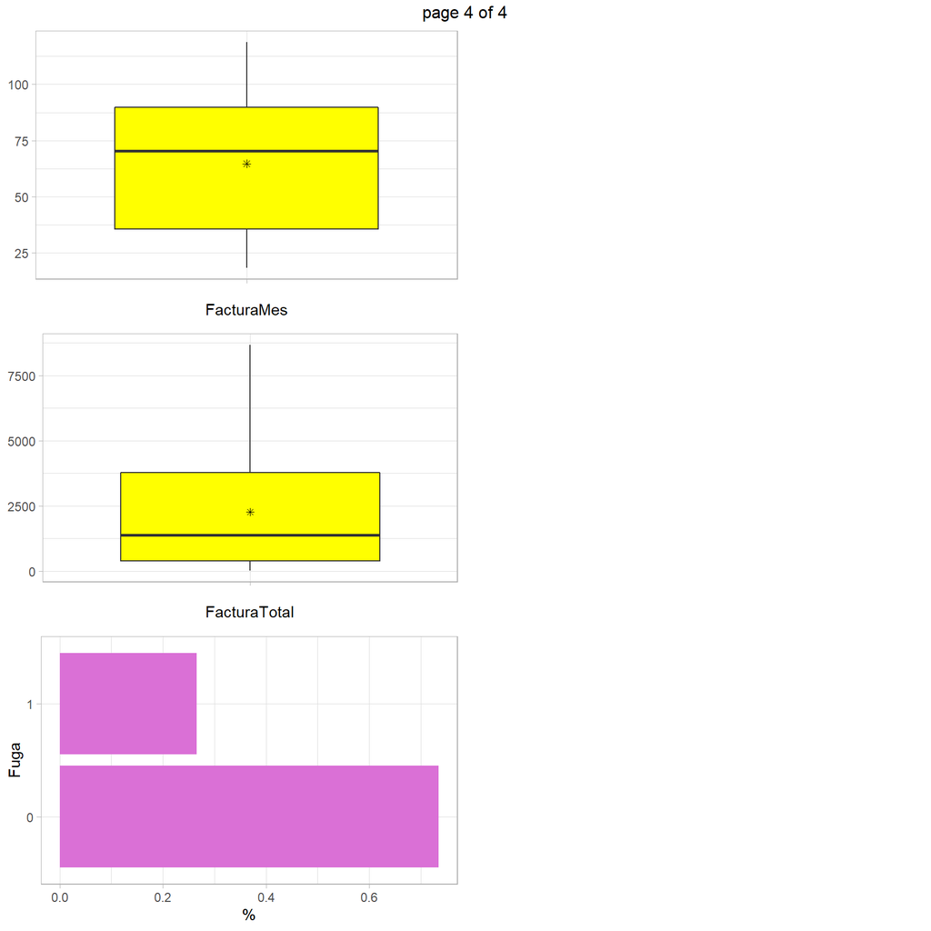

```r
gridExtra::marrangeGrob(listaGraf, nrow = 3, ncol = 2)
```

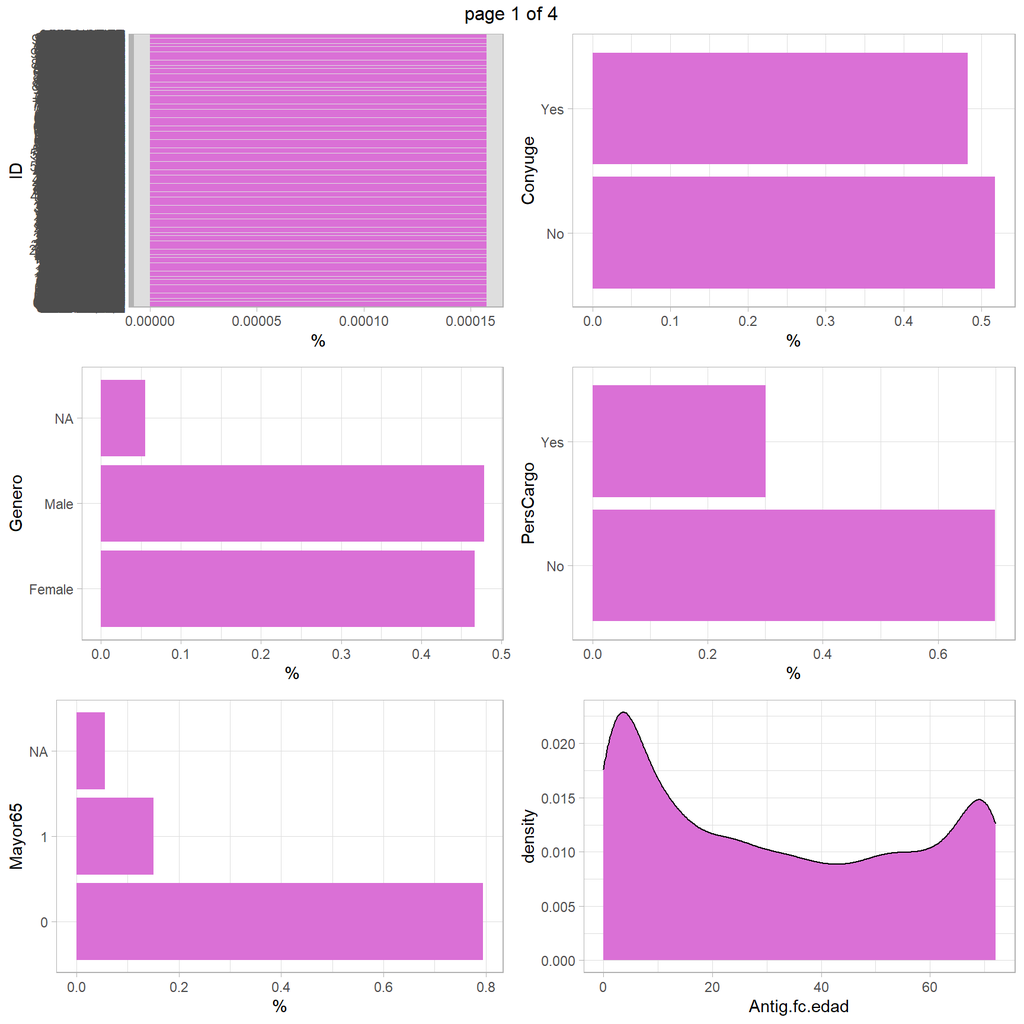

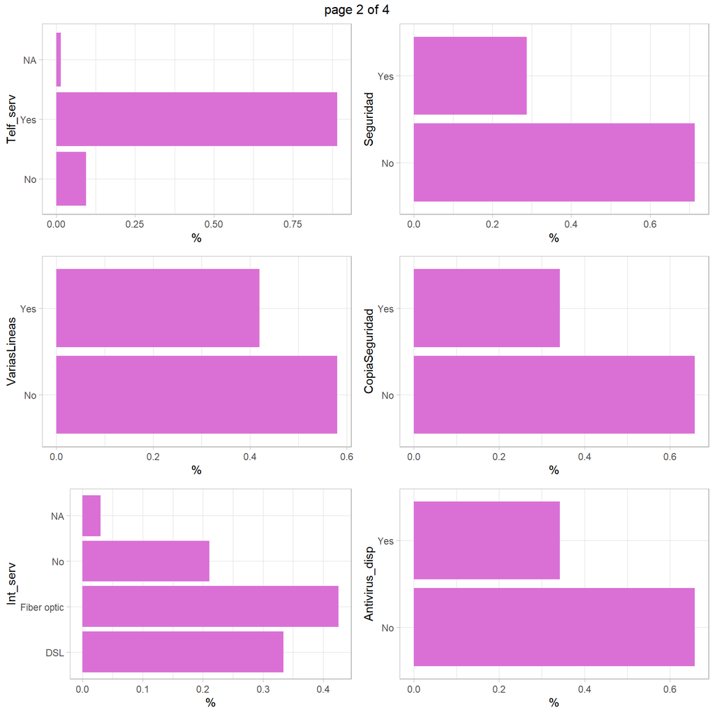

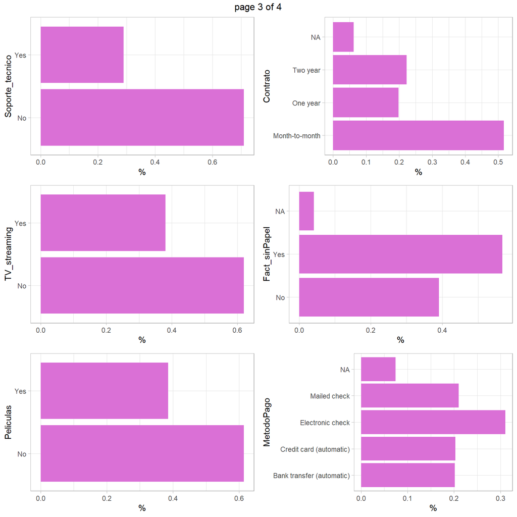

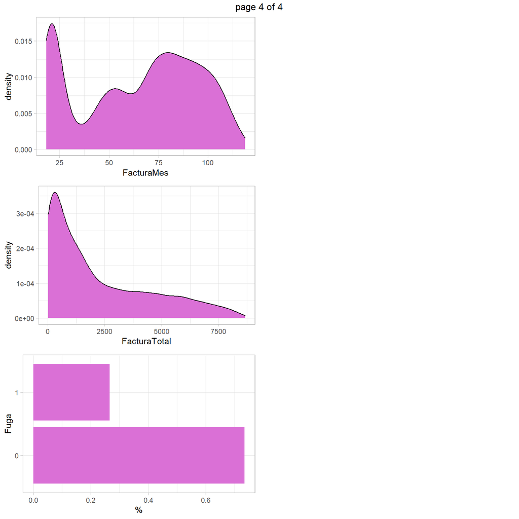

```r
gridExtra::marrangeGrob(listaHist, nrow = 3, ncol = 2)
```

Después de observar los gráficos realizados podemos ver como claramente hay valores nulos en el data set. También me he fijado en la distribución de Factura total, ya que en el boxplot podemos observar como hay una concentración de valores en la parte baja del gráfico, pero la representación llega hasta valores muy altos. Vamos a tener que analizar esto para determinar si son outliers. En la gráfica sobre la distribución de la densidad de los valores de la variable también se puede apreciar. Otra cosa con la que me quedo es el desbalanceo de la variable target. Para una correcta clasificación se tendría que balancear para tener la misma representación de cada clase para que el modelo sepa identificar si hay fuga o no de la misma manera y que no haya falsos negativos ni falsos positivos.

## 2) Depuración de los datos

```r
str(datos)
```

```
## 'data.frame':    6353 obs. of  21 variables:
##  $ ID             : Factor w/ 6353 levels "0002-ORFBO","0003-MKNFE",..: 4858 3587 2338 4997 5879 5915 911 4316 5063 4102 ...
##  $ Genero         : Factor w/ 2 levels "Female","Male": 1 2 2 NA 1 1 2 1 NA 2 ...
##  $ Mayor65        : Factor w/ 2 levels "0","1": 1 1 1 1 1 1 1 1 1 1 ...
##  $ Conyuge        : Factor w/ 2 levels "No","Yes": 2 1 1 1 1 1 1 1 2 1 ...
##  $ PersCargo      : Factor w/ 2 levels "No","Yes": 1 1 1 1 1 1 2 1 1 2 ...
##  $ Antig.fc.edad  : num  1 34 2 45 NA 8 22 10 28 62 ...
##  $ Telf_serv      : Factor w/ 2 levels "No","Yes": 1 2 2 1 2 2 2 1 2 2 ...
##  $ VariasLineas   : Factor w/ 2 levels "No","Yes": 1 1 1 1 1 2 2 1 2 1 ...
##  $ Int_serv       : Factor w/ 3 levels "DSL","Fiber optic",..: 1 1 1 1 2 2 2 NA 2 1 ...
##  $ Seguridad      : Factor w/ 2 levels "No","Yes": 1 2 2 2 1 1 1 2 1 2 ...
##  $ CopiaSeguridad : Factor w/ 2 levels "No","Yes": 2 1 2 1 1 1 2 1 1 2 ...
##  $ Antivirus_disp : Factor w/ 2 levels "No","Yes": 1 2 1 2 1 2 1 1 2 1 ...
##  $ Soporte_tecnico: Factor w/ 2 levels "No","Yes": 1 1 1 2 1 1 1 1 2 1 ...
##  $ TV_streaming   : Factor w/ 2 levels "No","Yes": 1 1 1 1 1 2 2 1 2 1 ...
##  $ Peliculas      : Factor w/ 2 levels "No","Yes": 1 1 1 1 1 2 1 1 2 1 ...
##  $ Contrato       : Factor w/ 3 levels "Month-to-month",..: 1 2 1 2 1 1 1 1 1 NA ...
##  $ Fact_sinPapel  : Factor w/ 2 levels "No","Yes": 2 1 2 1 2 2 2 1 2 1 ...
##  $ MetodoPago     : Factor w/ 4 levels "Bank transfer (automatic)",..: NA 4 4 NA 3 NA 2 4 3 NA ...
##  $ FacturaMes     : num  NA NA 53.9 42.3 70.7 ...
##  $ FacturaTotal   : num  29.9 1889.5 108.2 1840.8 151.7 ...
##  $ Fuga           : Factor w/ 2 levels "0","1": 1 1 2 1 2 2 1 1 2 1 ...
```

```r
varObjBin <- datos$Fuga

varObjBin <- as.numeric(varObjBin)

varObjBin[varObjBin == 1] <- 0

varObjBin[varObjBin == 2] <- 1

varObjBin <- as.factor(varObjBin)

datos <- datos[,-21]
```

Creo un objeto con la variable objetivo ya que más adelante la voy a eliminar del dataset para que no sea alterada por error. También la he pasado a 0 y 1 para el modelado.

```r
nrow(datos)
```

```
## [1] 6353
```

```r
datos$ID <- as.numeric(datos$ID)
```

```r
sapply(Filter(is.numeric, datos),
       function(x) atipicosAmissing(x)[[2]])/nrow(datos)
```

```
##            ID Antig.fc.edad    FacturaMes  FacturaTotal
##             0             0             0             0
```

Podemos observar como no existen atípicos en el dataset. Al ver esto he vuelto a revisar el summary, histograma y boxplot que he creado antes para ver la distribución de estas variables.

FacturaMes y Antig.fc.edad son dos variables que en el summary vemos como tienen valores muy coherentes en relación al mínimo, máximo, mediana y los cuartiles son lógicos.

En la variable FacturaTotal si que la distribución no es tan lógica ya que el máximo se distancia mucho del 3er cuartil. Más o menos es una variable lógica cómo las demás pero me hace sospechar que el máximo sea más del doble que el 3er cuartil, pero según esta función sale que no existe ningún outlier. Si nos fijamos en el boxplot podemos ver como toda la muestra se concentra en la parte baja del gráfico pero sube hasta los 8700. En el histograma vemos lo mismo, pero podría ser que haya una FacturaTotal muy elevada, el problema estaría si nos complica el modelado.

```r
t<-data.frame(sort(
  round(sapply(Filter(
    is.numeric, datos),function(nOut) atipicosAmissing(
      nOut)[[2]])/nrow(datos)*100,3), decreasing = T))
names(t)<-"% Outliers por variable"
t
```

```
##               % Outliers por variable
## ID                                  0
## Antig.fc.edad                       0
## FacturaMes                          0
## FacturaTotal                        0
```

Al representar la tabla con el porcentaje de outliers por variable vemos como también no sale 0.

Al no estar muy seguro de estas conclusiones voy a realizar el método Local Outlier Factor para ver si existen outliers. Si los valores están cerca del valor 1 nos va a explicar que las observaciones están cerca de la media, sinó vamos a sospechar de posibles outliers.

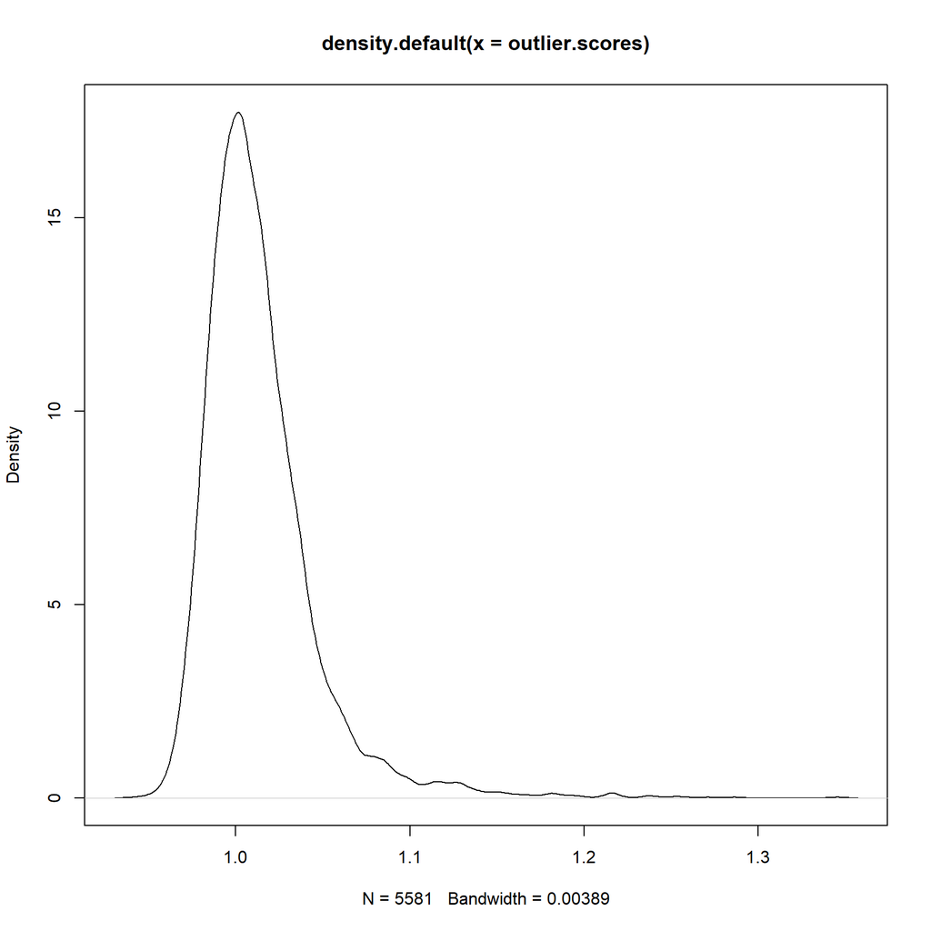

```r
outlier.scores <- lofactor(na.omit(Filter(is.numeric, datos)), k=20)
plot(density(outlier.scores))
```

Podemos observar como calaramente hay valores fuera de la media y con lo cual vamos a tener que tratarlos.

```r
outliers <- order(outlier.scores, decreasing=T)[1:10]
```

Selecciono los 10 valores con el índice de outlier más grande.

```r
(na.omit(Filter(is.numeric, datos))[outliers,] ->out5)
```

```
##        ID Antig.fc.edad FacturaMes FacturaTotal
## 2135 4272            72     117.15      8529.50
## 4460 6345             1      18.90        18.90
## 6109 6195            72     117.50      8670.10
## 6295 6343            53      94.00      4871.45
## 5626 6336             1      20.05        20.05
## 1043 5034             2      95.15       196.90
## 5326 6324            67      75.70      5060.85
## 3795   11            72     116.80      8456.75
## 775  3857            72     115.80      8476.50
## 3465    3             4      73.90       280.85
```

Claramente podemos ver como hay valores que no tienen un sentido y se relacionan entre ellas. Podemos ver como Antig.fc.edad hay valores como 72, 53, 67… Estos elementos dicen que una persona se ha pasado 72 años en una misma compañia, me parece raro ya que es toda una vida. Justamente estas personas tienen unas FacturaTotal de 8670 euros, es muchisimo. También podemos ver si multiplicamos FacturaMes = 117 euros (que es un valor alto en la muestra) por 12 no sale un valor de 1400 euros. Podría ser que en algún momento sea más o menos pero nunca 8600 euros.

Por todo esto, voy a tratar estos atípicos. Los voy a substituir por NA’s y luego los voy a tratar con el preprocesado de ausentes.

```r
out5$ID -> ID_out5
```

```r
data.frame(t(round(apply(na.omit(Filter(is.numeric, datos)),2,mean),3)))
```

```
##         ID Antig.fc.edad FacturaMes FacturaTotal
## 1 3173.774        32.507     65.071     2293.917
```

```r
data.frame(t(round(apply(na.omit(Filter(is.numeric, datos)),2,median),3)))
```

```
##     ID Antig.fc.edad FacturaMes FacturaTotal
## 1 3169            29      70.55       1405.3
```

Podemos ver como al comparar los valores hay una gran diferencia.

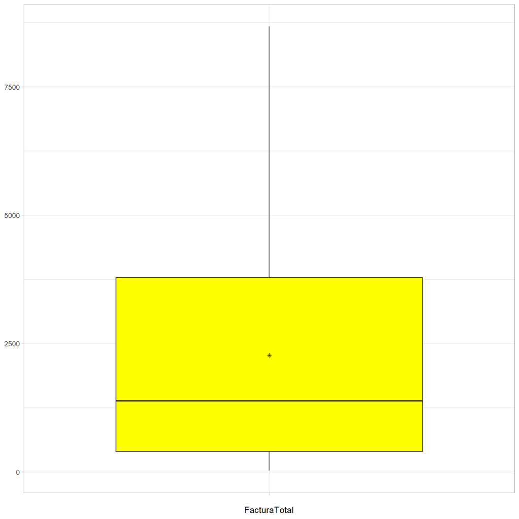

```r
boxplot_cont(datos$FacturaTotal,nombreEje = 'FacturaTotal')
```

La distribución de FacturaTotal está muy apuntada pero existen observaciones muy por encima de la media.

```r
datos[,as.vector(which(sapply(
  datos, class)=="numeric"))]<-sapply(Filter(
    is.numeric, datos),function(x) atipicosAmissing(x)[[1]])
```

## Perdidos

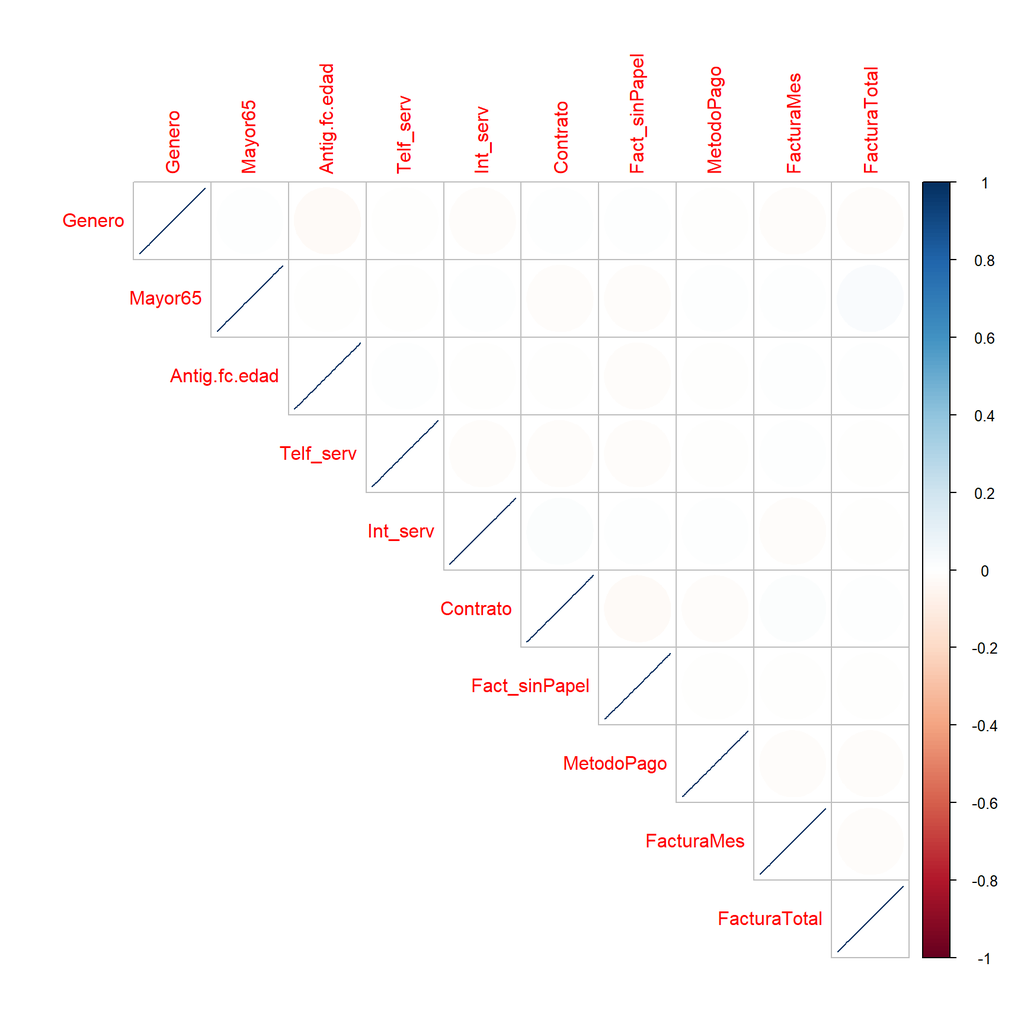

```r
corrplot(cor(is.na(datos[colnames(
  datos)[colSums(is.na(datos))>0]])),method = "ellipse",type = "upper")
```

Para tratar los mising vamos va empezar observando si hay correlación entre las variables que contienen NA’s. Podemos concluir que no hay correlación en ninguna variable.

```r
prop_missingsVars<-apply(is.na(datos),2,mean)
```

```r
t<-data.frame(sort(prop_missingsVars*100, decreasing = T))
names(t)<-"% Missing por Variable"
t
```

```
##                 % Missing por Variable
## MetodoPago                   7.4295608
## Antig.fc.edad                6.2017944
## Contrato                     6.2017944
## FacturaMes                   6.2017944
## Genero                       5.5406894
## Mayor65                      5.5406894
## Fact_sinPapel                4.1082953
## Int_serv                     2.9907130
## Telf_serv                    1.4481347
## FacturaTotal                 0.1731465
## ID                           0.0000000
## Conyuge                      0.0000000
## PersCargo                    0.0000000
## VariasLineas                 0.0000000
## Seguridad                    0.0000000
## CopiaSeguridad               0.0000000
## Antivirus_disp               0.0000000
## Soporte_tecnico              0.0000000
## TV_streaming                 0.0000000
## Peliculas                    0.0000000
```

Estas son las variables que tienen misings. Al tener un porcentaje bajo vamos a tratar a todas las variables.

```r
datos$prop_missings<-apply(is.na(datos),1,mean)
summary(datos$prop_missings)
```

```
##    Min. 1st Qu.  Median    Mean 3rd Qu.    Max.
## 0.00000 0.00000 0.00000 0.02292 0.05000 0.15000
```

```r
datos %>% arrange(desc(prop_missings)) %>% slice_head(n=5)
```

```
##     ID Genero Mayor65 Conyuge PersCargo Antig.fc.edad Telf_serv VariasLineas
## 1 1798 Female    <NA>      No        No            NA       Yes           No
## 2 4795   <NA>       0     Yes       Yes            NA       Yes           No
## 3 4866 Female    <NA>      No        No            65       Yes           No
## 4 6029   Male    <NA>     Yes        No             8      <NA>           No
## 5 2467   <NA>       0     Yes       Yes            16        No           No
##   Int_serv Seguridad CopiaSeguridad Antivirus_disp Soporte_tecnico TV_streaming
## 1       No        No             No             No              No           No
## 2      DSL        No             No            Yes             Yes          Yes
## 3     <NA>       Yes            Yes             No             Yes           No
## 4      DSL       Yes             No             No              No          Yes
## 5      DSL        No             No             No              No           No
##   Peliculas       Contrato Fact_sinPapel                MetodoPago FacturaMes
## 1        No Month-to-month            No                      <NA>      19.55
## 2       Yes       Two year          <NA> Bank transfer (automatic)      73.80
## 3        No       Two year           Yes                      <NA>      59.60
## 4        No Month-to-month            No                      <NA>      60.90
## 5       Yes           <NA>          <NA>   Credit card (automatic)      35.50
##   FacturaTotal prop_missings
## 1        19.55          0.15
## 2      4616.05          0.15
## 3      3739.80          0.15
## 4       551.95          0.15
## 5       552.70          0.15
```

```r
datos[,as.vector(which(sapply(datos, class)=="numeric"))]<-sapply(
  Filter(is.numeric, datos),function(x) ImputacionCuant(x,"media"))

datos[,as.vector(which(sapply(datos, class)=="factor"))]<-sapply(
  Filter(is.factor, datos),function(x) ImputacionCuali(x,"aleatorio"))

datos[,as.vector(which(sapply(datos, class)=="character"))] <- lapply(
  datos[,as.vector(which(sapply(datos, class)=="character"))] , factor)
```

```r
if (any(is.na(datos))){
  datos[,as.vector(which(sapply(datos, class)=="numeric"))]<-sapply(
    Filter(is.numeric, datos),function(x) ImputacionCuant(x,"aleatorio"))
}

summary(datos)
```

```
##        ID          Genero     Mayor65  Conyuge    PersCargo  Antig.fc.edad
##  Min.   :   1   Female:3131   0:5333   No :3287   No :4439   Min.   : 0.00
##  1st Qu.:1589   Male  :3222   1:1020   Yes:3066   Yes:1914   1st Qu.:10.00
##  Median :3177                                                Median :32.00
##  Mean   :3177                                                Mean   :32.38
##  3rd Qu.:4765                                                3rd Qu.:54.00
##  Max.   :6353                                                Max.   :72.00
##  Telf_serv  VariasLineas        Int_serv    Seguridad  CopiaSeguridad
##  No : 622   No :3687     DSL        :2182   No :4532   No :4180
##  Yes:5731   Yes:2666     Fiber optic:2796   Yes:1821   Yes:2173
##                          No         :1375
##
##
##
##  Antivirus_disp Soporte_tecnico TV_streaming Peliculas            Contrato
##  No :4180       No :4509        No :3936     No :3902   Month-to-month:3495
##  Yes:2173       Yes:1844        Yes:2417     Yes:2451   One year      :1349
##                                                         Two year      :1509
##
##
##
##  Fact_sinPapel                     MetodoPago     FacturaMes
##  No :2588      Bank transfer (automatic):1375   Min.   : 18.25
##  Yes:3765      Credit card (automatic)  :1391   1st Qu.: 41.10
##                Electronic check         :2133   Median : 68.75
##                Mailed check             :1454   Mean   : 64.68
##                                                 3rd Qu.: 89.00
##                                                 Max.   :118.75
##   FacturaTotal    prop_missings
##  Min.   :  18.8   Min.   :0.00000
##  1st Qu.: 396.3   1st Qu.:0.00000
##  Median :1387.3   Median :0.00000
##  Mean   :2268.7   Mean   :0.02292
##  3rd Qu.:3778.0   3rd Qu.:0.05000
##  Max.   :8672.5   Max.   :0.15000
```

De esta forma he imputado los valores NA’s. Como podemos observar ahora el dataset está listo para hacer un estudio de las variables y el posterior modelado para conseguir, finalmente, la predicción deseada.

## 3) Estudio de variables y relaciones con la variable objetivo

> Creamos variables aleatorias

```r
datos <- datos[,-1]
```

Elimino la variable ID.

```r
datos$aleatorio<-runif(nrow(datos))

datos$aleatorio2<-runif(nrow(datos))
```

Creo dos varaibles de control para evaluar los efectos de los predictores frente a la respuesta.

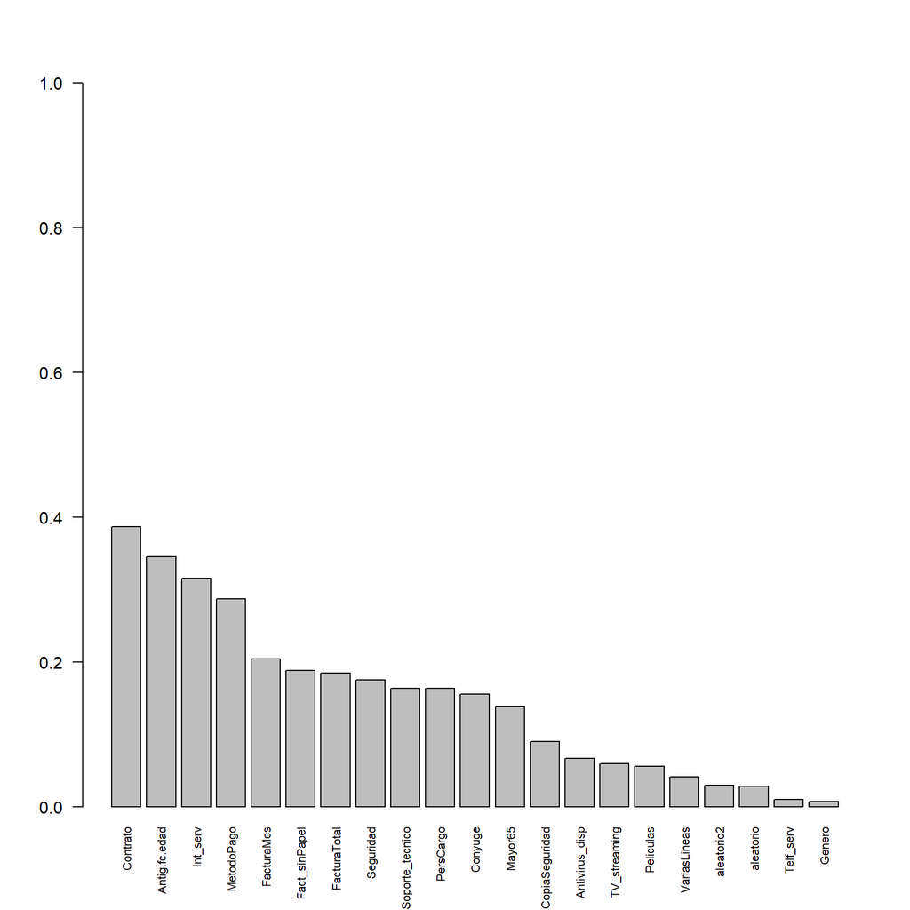

```r
graficoVcramer(datos,varObjBin)
```

Podemos observar las variables que tentativas para el modelado:

- Contrato
- Antig.fc.edad
- Int_serv
- MetodoPago
- FacturaMes
- Fact_sinPapel
- FacturaTotal
- Seguridad
- Soporte_tecnico
- PersCargo
- Conyuge
- Mayor65
- CopiaSeguridad
- Antivirus_disp
- TV_streaming
- Peliculas
- VariasLineas

A partir de aquí aparecen las aleatorias, con lo cual vamos a prescindir de las que vienen detrás.

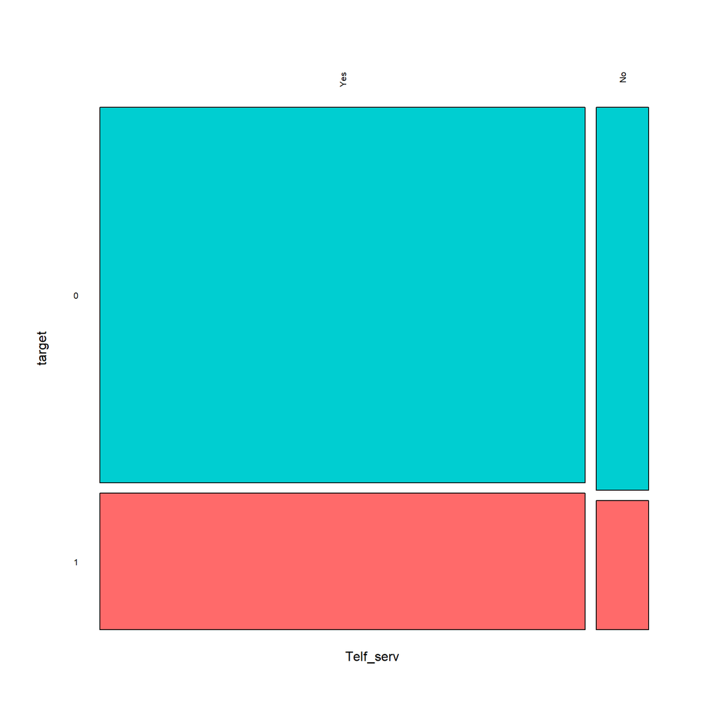

```r
m1<-mosaico_targetbinaria(datos$Telf_serv,varObjBin,"Telf_serv")
```

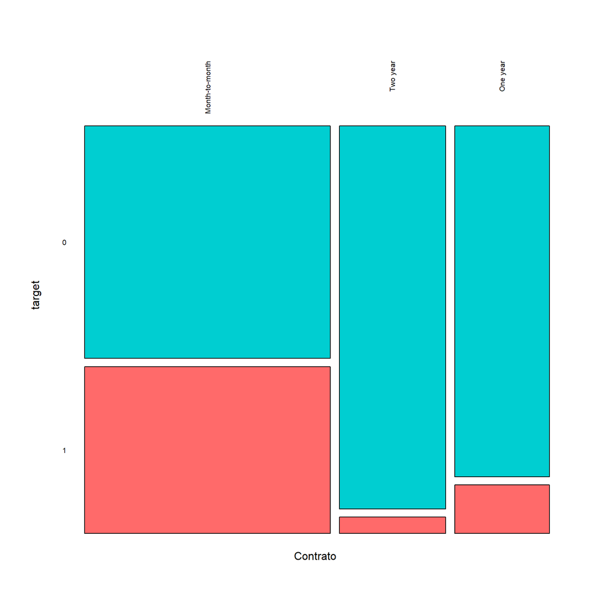

```r
m2<-mosaico_targetbinaria(datos$Contrato,varObjBin,"Contrato")
```

```r
bx1<-boxplot_targetbinaria(datos$Antig.fc.edad,varObjBin,"Antig.fc.edad")
bx2<-boxplot_targetbinaria(datos$FacturaMes,varObjBin,"FacturaMes")
bx3<-boxplot_targetbinaria(datos$FacturaTotal,varObjBin,"FacturaTotal")
```

```r
h1<-hist_targetbinaria(datos$Antig.fc.edad,varObjBin,"Antig.fc.edad")
h2<-hist_targetbinaria(datos$FacturaMes,varObjBin,"FacturaMes")
h3<-hist_targetbinaria(datos$FacturaTotal,varObjBin,"FacturaTotal")
```

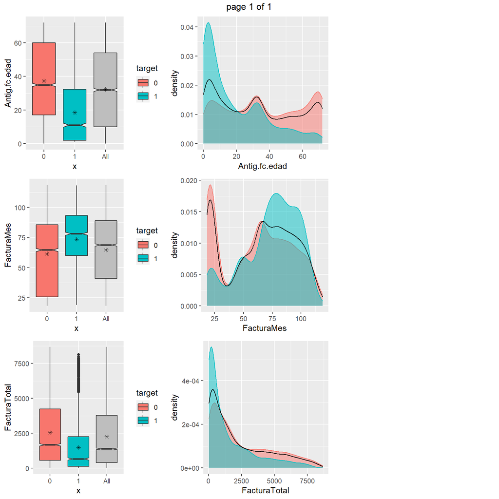

```r
marrangeGrob(list(bx1,bx2,bx3,h1,h2,h3),nrow = 3,ncol = 3)
```

Vemos como V de cramer no miente ya que vemos un solapamiento entre las dos variables. Podemos observar como en FacturaMes y Antig.fc.edad hay valores que no están solapados.

Las tres variables tienen influencia en el respuesta binaria. Podemos apreciar que cuanto más tiempo se quedan más probabilidad de que no haya fuga, si la FacturaMes es más elevada tienden a Fuga y en FacturaTotal hay mcuhos puntos en valores altos de la gráfica en target = 1.

> TRANSFORMACIÓN DE VARIABLES

Vamos a generar las transformaciones de las variable continuas que maximizan la relación con la variable objetivo binaria en sentido de V de Cramer.

```r
datos <- datos[,-20]

Vcramer<-function(v,target){
  if (is.numeric(v)){
    v<-cut(v,min(5,length(unique(v))))
  }
  if (is.numeric(target)){
    target<-cut(target,5)
  }
  cramer.v(table(v,target))
}
```

```r
input_bin<-cbind(datos,Transf_Auto(Filter(is.numeric, datos),varObjBin))
todo_bin<-data.frame(input_bin,varObjBin)
```

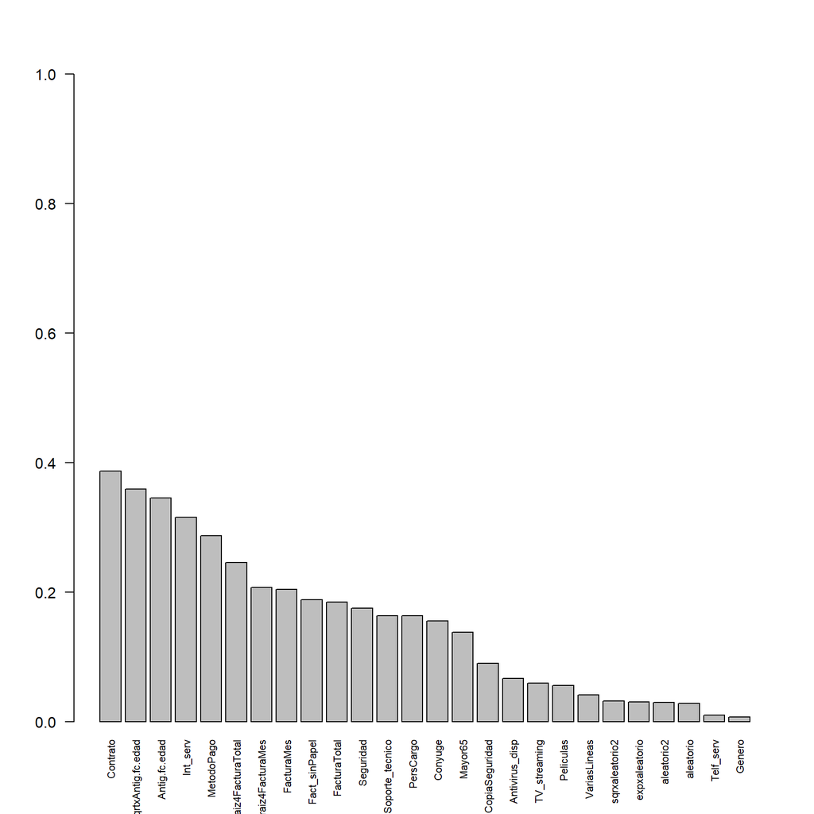

```r
graficoVcramer(input_bin,varObjBin)
```

Aún creando transformaciones podemos ver como sigue más o menos la misma distribución que sin las transformaciones.

## 4) Modelado manual

```r
todo<-todo_bin
freq(todo$varObjBin)
```

```
##      n    % val%
## 0 4667 73.5 73.5
## 1 1686 26.5 26.5
```

Sabía que la muestra estaba desbalanceada, concretamente la muestra está compuesta por un 73.5% en valores 0 y un 26.5% en valores 1.

```r
names(todo)
```

```
##  [1] "Genero"             "Mayor65"            "Conyuge"
##  [4] "PersCargo"          "Antig.fc.edad"      "Telf_serv"
##  [7] "VariasLineas"       "Int_serv"           "Seguridad"
## [10] "CopiaSeguridad"     "Antivirus_disp"     "Soporte_tecnico"
## [13] "TV_streaming"       "Peliculas"          "Contrato"
## [16] "Fact_sinPapel"      "MetodoPago"         "FacturaMes"
## [19] "FacturaTotal"       "aleatorio"          "aleatorio2"
## [22] "sqrtxAntig.fc.edad" "raiz4FacturaMes"    "raiz4FacturaTotal"
## [25] "expxaleatorio"      "sqrxaleatorio2"     "varObjBin"
```

Vamos a generar la partición del archivo en el que incluiremos solamente las variables originales.

```r
set.seed(123456)
trainIndex <- createDataPartition(todo$varObjBin, p=0.8, list=FALSE)
data_train <- todo[trainIndex,c(1:21,27)]
data_test <- todo[-trainIndex,c(1:21,27)]
```

```r
modeloInicial<-glm(varObjBin~.,data=data_train,family=binomial)
summary(modeloInicial)
```

```
##
## Call:
## glm(formula = varObjBin ~ ., family = binomial, data = data_train)
##
## Deviance Residuals:
##     Min       1Q   Median       3Q      Max
## -2.0548  -0.6632  -0.3049   0.6565   3.2029
##
## Coefficients:
##                                     Estimate Std. Error z value Pr(>|z|)
## (Intercept)                       -3.188e-01  2.474e-01  -1.288 0.197618
## GeneroMale                        -2.541e-02  7.668e-02  -0.331 0.740368
## Mayor651                           2.494e-01  1.013e-01   2.462 0.013814 *
## ConyugeYes                        -4.193e-02  9.243e-02  -0.454 0.650100
## PersCargoYes                      -1.753e-01  1.051e-01  -1.668 0.095301 .
## Antig.fc.edad                     -3.426e-02  4.697e-03  -7.296 2.97e-13 ***
## Telf_servYes                      -7.425e-01  1.715e-01  -4.330 1.49e-05 ***
## VariasLineasYes                    3.271e-01  9.663e-02   3.384 0.000713 ***
## Int_servFiber optic                7.968e-01  1.463e-01   5.445 5.17e-08 ***
## Int_servNo                        -4.602e-01  1.749e-01  -2.631 0.008526 **
## SeguridadYes                      -4.874e-01  1.043e-01  -4.673 2.97e-06 ***
## CopiaSeguridadYes                 -2.024e-01  9.541e-02  -2.121 0.033929 *
## Antivirus_dispYes                 -6.613e-02  9.752e-02  -0.678 0.497745
## Soporte_tecnicoYes                -3.834e-01  1.042e-01  -3.679 0.000234 ***
## TV_streamingYes                    2.986e-01  1.065e-01   2.803 0.005061 **
## PeliculasYes                       1.443e-01  1.050e-01   1.374 0.169519
## ContratoOne year                  -6.930e-01  1.207e-01  -5.743 9.31e-09 ***
## ContratoTwo year                  -1.309e+00  1.764e-01  -7.423 1.14e-13 ***
## Fact_sinPapelYes                   3.777e-01  8.700e-02   4.341 1.42e-05 ***
## MetodoPagoCredit card (automatic) -1.470e-01  1.316e-01  -1.117 0.263874
## MetodoPagoElectronic check         2.280e-01  1.106e-01   2.061 0.039270 *
## MetodoPagoMailed check            -6.403e-02  1.300e-01  -0.493 0.622348
## FacturaMes                         7.170e-03  4.501e-03   1.593 0.111186
## FacturaTotal                      -2.605e-05  5.659e-05  -0.460 0.645334
## aleatorio                          7.599e-02  1.350e-01   0.563 0.573638
## aleatorio2                         1.573e-01  1.340e-01   1.173 0.240656
## ---
## Signif. codes:  0 '***' 0.001 '**' 0.01 '*' 0.05 '.' 0.1 ' ' 1
##
## (Dispersion parameter for binomial family taken to be 1)
##
##     Null deviance: 5882.3  on 5082  degrees of freedom
## Residual deviance: 4212.1  on 5057  degrees of freedom
## AIC: 4264.1
##
## Number of Fisher Scoring iterations: 6
```

Hay muchos elementos no significativos pero he decidido unir la categoria MetodoPago para ver si obtengo mejores resultados.

```r
table(todo$MetodoPago,todo$varObjBin)
```

```
##
##                                0    1
##   Bank transfer (automatic) 1130  245
##   Credit card (automatic)   1180  211
##   Electronic check          1189  944
##   Mailed check              1168  286
```

```r
table(data_train$MetodoPago,data_train$varObjBin)
```

```
##
##                               0   1
##   Bank transfer (automatic) 907 200
##   Credit card (automatic)   947 177
##   Electronic check          951 743
##   Mailed check              929 229
```

Podemos observar que hay muy poca representación de valores 1 en Bank transfer (automatic), Credit card (automatic) y Mailed check. Voy a unir esta categoria en dos.

```r
todo$MetodoPago<-car::recode(todo$MetodoPago, "c('Bank transfer (automatic)','Credit card (automatic)','Mailed check') = 'Bank_transfer'")
```

```r
set.seed(123456)
trainIndex <- createDataPartition(todo$varObjBin, p=0.8, list=FALSE)
data_train <- todo[trainIndex,c(1:21,27)]
data_test <- todo[-trainIndex,c(1:21,27)]
```

```r
modeloInicial<-glm(varObjBin~.,data=data_train,family=binomial)
summary(modeloInicial)
```

```
##
## Call:
## glm(formula = varObjBin ~ ., family = binomial, data = data_train)
##
## Deviance Residuals:
##     Min       1Q   Median       3Q      Max
## -2.0551  -0.6679  -0.3031   0.6549   3.1788
##
## Coefficients:
##                              Estimate Std. Error z value Pr(>|z|)
## (Intercept)                -3.952e-01  2.278e-01  -1.735 0.082796 .
## GeneroMale                 -2.649e-02  7.665e-02  -0.346 0.729645
## Mayor651                    2.517e-01  1.012e-01   2.486 0.012912 *
## ConyugeYes                 -4.082e-02  9.240e-02  -0.442 0.658665
## PersCargoYes               -1.754e-01  1.051e-01  -1.669 0.095183 .
## Antig.fc.edad              -3.424e-02  4.676e-03  -7.323 2.43e-13 ***
## Telf_servYes               -7.369e-01  1.712e-01  -4.304 1.68e-05 ***
## VariasLineasYes             3.263e-01  9.655e-02   3.380 0.000725 ***
## Int_servFiber optic         7.968e-01  1.463e-01   5.447 5.12e-08 ***
## Int_servNo                 -4.590e-01  1.746e-01  -2.629 0.008555 **
## SeguridadYes               -4.856e-01  1.043e-01  -4.656 3.22e-06 ***
## CopiaSeguridadYes          -2.015e-01  9.541e-02  -2.112 0.034676 *
## Antivirus_dispYes          -6.666e-02  9.747e-02  -0.684 0.494053
## Soporte_tecnicoYes         -3.850e-01  1.042e-01  -3.696 0.000219 ***
## TV_streamingYes             2.986e-01  1.065e-01   2.804 0.005050 **
## PeliculasYes                1.452e-01  1.050e-01   1.383 0.166788
## ContratoOne year           -6.924e-01  1.206e-01  -5.741 9.42e-09 ***
## ContratoTwo year           -1.309e+00  1.764e-01  -7.421 1.16e-13 ***
## Fact_sinPapelYes            3.765e-01  8.696e-02   4.330 1.49e-05 ***
## MetodoPagoElectronic check  2.969e-01  8.190e-02   3.625 0.000289 ***
## FacturaMes                  7.188e-03  4.496e-03   1.599 0.109842
## FacturaTotal               -2.703e-05  5.652e-05  -0.478 0.632522
## aleatorio                   7.930e-02  1.350e-01   0.587 0.556914
## aleatorio2                  1.585e-01  1.340e-01   1.183 0.236909
## ---
## Signif. codes:  0 '***' 0.001 '**' 0.01 '*' 0.05 '.' 0.1 ' ' 1
##
## (Dispersion parameter for binomial family taken to be 1)
##
##     Null deviance: 5882.3  on 5082  degrees of freedom
## Residual deviance: 4213.4  on 5059  degrees of freedom
## AIC: 4261.4
##
## Number of Fisher Scoring iterations: 6
```

```r
pseudoR2(modeloInicial,data_train,"varObjBin")
```

```
## [1] 0.2837138
```

```r
pseudoR2(modeloInicial,data_test,"varObjBin")
```

```
## [1] 0.2544433
```

```r
modeloInicial$rank
```

```
## [1] 24
```

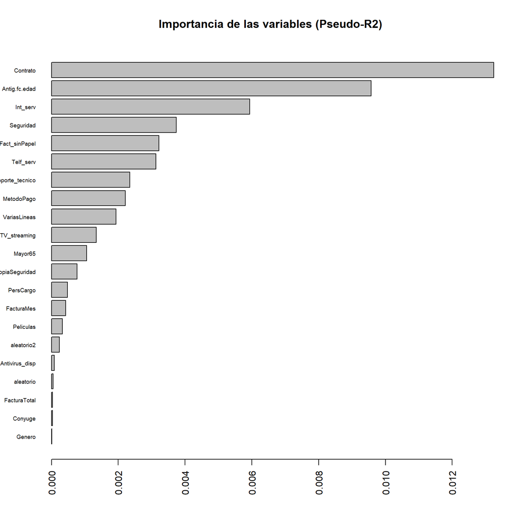

```r
impVariablesLog(modeloInicial,"varObjBin")
```

- Vemos un modelo un poco más estrellado si lo comparo con el que no tiene la transformación de MetodoPago.
- En este modelo la pseudo R2 es mayor en train que en test, con lo que le costará más predecir con datos nuevos.
- Podemos observar en el gráfico finalnos enseña de forma ordenada las aportaciones de pseudo R2 de las distintas variables donde Contrato es la ganadora con diferencia, seguida de Antig.fc.edad y Int_serv.

```r
modelo2<-glm(varObjBin~Contrato+Antig.fc.edad+Int_serv+Seguridad+Fact_sinPapel+
               Telf_serv+MetodoPago+Soporte_tecnico+VariasLineas+TV_streaming+
               CopiaSeguridad+FacturaMes+Mayor65,
             data=data_train,family=binomial)
summary(modelo2)
```

```
##
## Call:
## glm(formula = varObjBin ~ Contrato + Antig.fc.edad + Int_serv +
##     Seguridad + Fact_sinPapel + Telf_serv + MetodoPago + Soporte_tecnico +
##     VariasLineas + TV_streaming + CopiaSeguridad + FacturaMes +
##     Mayor65, family = binomial, data = data_train)
##
## Deviance Residuals:
##     Min       1Q   Median       3Q      Max
## -2.0364  -0.6640  -0.3036   0.6739   3.1787
##
## Coefficients:
##                             Estimate Std. Error z value Pr(>|z|)
## (Intercept)                -0.346542   0.183301  -1.891 0.058683 .
## ContratoOne year           -0.705926   0.119571  -5.904 3.55e-09 ***
## ContratoTwo year           -1.338743   0.175128  -7.644 2.10e-14 ***
## Antig.fc.edad              -0.036558   0.002566 -14.248  < 2e-16 ***
## Int_servFiber optic         0.761767   0.138923   5.483 4.17e-08 ***
## Int_servNo                 -0.430101   0.171561  -2.507 0.012176 *
## SeguridadYes               -0.506009   0.102746  -4.925 8.44e-07 ***
## Fact_sinPapelYes            0.382479   0.086619   4.416 1.01e-05 ***
## Telf_servYes               -0.794491   0.163548  -4.858 1.19e-06 ***
## MetodoPagoElectronic check  0.308477   0.081480   3.786 0.000153 ***
## Soporte_tecnicoYes         -0.401822   0.103160  -3.895 9.82e-05 ***
## VariasLineasYes             0.314399   0.094667   3.321 0.000897 ***
## TV_streamingYes             0.291344   0.104797   2.780 0.005435 **
## CopiaSeguridadYes          -0.230322   0.092934  -2.478 0.013200 *
## FacturaMes                  0.008983   0.003891   2.309 0.020959 *
## Mayor651                    0.279236   0.099329   2.811 0.004935 **
## ---
## Signif. codes:  0 '***' 0.001 '**' 0.01 '*' 0.05 '.' 0.1 ' ' 1
##
## (Dispersion parameter for binomial family taken to be 1)
##
##     Null deviance: 5882.3  on 5082  degrees of freedom
## Residual deviance: 4222.6  on 5067  degrees of freedom
## AIC: 4254.6
##
## Number of Fisher Scoring iterations: 6
```

```r
pseudoR2(modelo2,data_train,"varObjBin")
```

```
## [1] 0.2821464
```

```r
pseudoR2(modelo2,data_test,"varObjBin")
```

```
## [1] 0.2541385
```

```r
modelo2$rank
```

```
## [1] 16
```

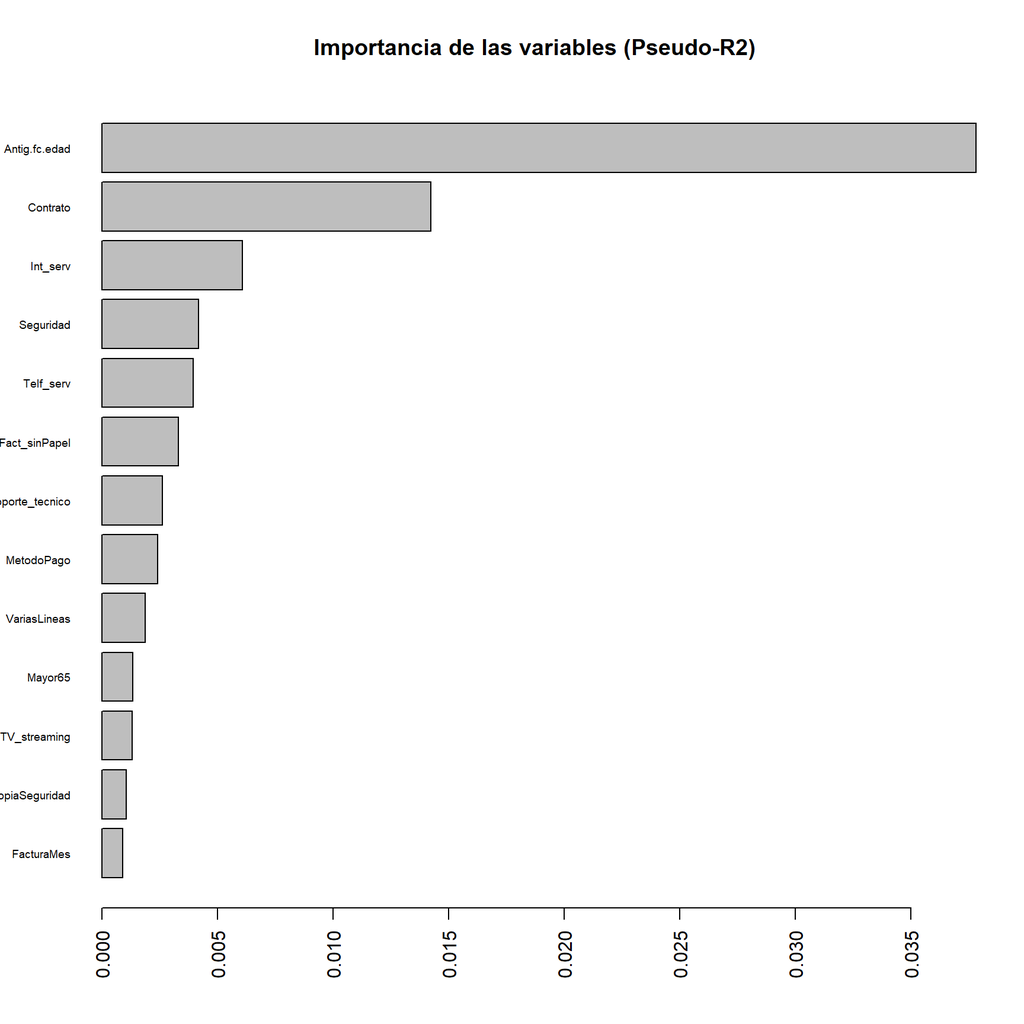

```r
impVariablesLog(modelo2,'varObjBin')
```

```r
modelo3<-glm(varObjBin~Contrato+Antig.fc.edad+Int_serv+Seguridad+Fact_sinPapel+
               Telf_serv+MetodoPago+Soporte_tecnico+VariasLineas,
             data=data_train,family=binomial)
summary(modelo3)
```

```
##
## Call:
## glm(formula = varObjBin ~ Contrato + Antig.fc.edad + Int_serv +
##     Seguridad + Fact_sinPapel + Telf_serv + MetodoPago + Soporte_tecnico +
##     VariasLineas, family = binomial, data = data_train)
##
## Deviance Residuals:
##     Min       1Q   Median       3Q      Max
## -1.8493  -0.6622  -0.3115   0.6936   3.1195
##
## Coefficients:
##                             Estimate Std. Error z value Pr(>|z|)
## (Intercept)                -0.040979   0.143807  -0.285 0.775679
## ContratoOne year           -0.677877   0.118302  -5.730 1.00e-08 ***
## ContratoTwo year           -1.310868   0.174345  -7.519 5.53e-14 ***
## Antig.fc.edad              -0.034690   0.002412 -14.381  < 2e-16 ***
## Int_servFiber optic         1.058157   0.104294  10.146  < 2e-16 ***
## Int_servNo                 -0.678048   0.147011  -4.612 3.98e-06 ***
## SeguridadYes               -0.480103   0.100216  -4.791 1.66e-06 ***
## Fact_sinPapelYes            0.423326   0.085838   4.932 8.15e-07 ***
## Telf_servYes               -0.679529   0.147376  -4.611 4.01e-06 ***
## MetodoPagoElectronic check  0.372573   0.080383   4.635 3.57e-06 ***
## Soporte_tecnicoYes         -0.329710   0.099326  -3.319 0.000902 ***
## VariasLineasYes             0.411573   0.090319   4.557 5.19e-06 ***
## ---
## Signif. codes:  0 '***' 0.001 '**' 0.01 '*' 0.05 '.' 0.1 ' ' 1
##
## (Dispersion parameter for binomial family taken to be 1)
##
##     Null deviance: 5882.3  on 5082  degrees of freedom
## Residual deviance: 4260.9  on 5071  degrees of freedom
## AIC: 4284.9
##
## Number of Fisher Scoring iterations: 6
```

```r
pseudoR2(modelo3,data_train,"varObjBin")
```

```
## [1] 0.2756329
```

```r
pseudoR2(modelo3,data_test,"varObjBin")
```

```
## [1] 0.2497814
```

```r
modelo3$rank
```

```
## [1] 12
```

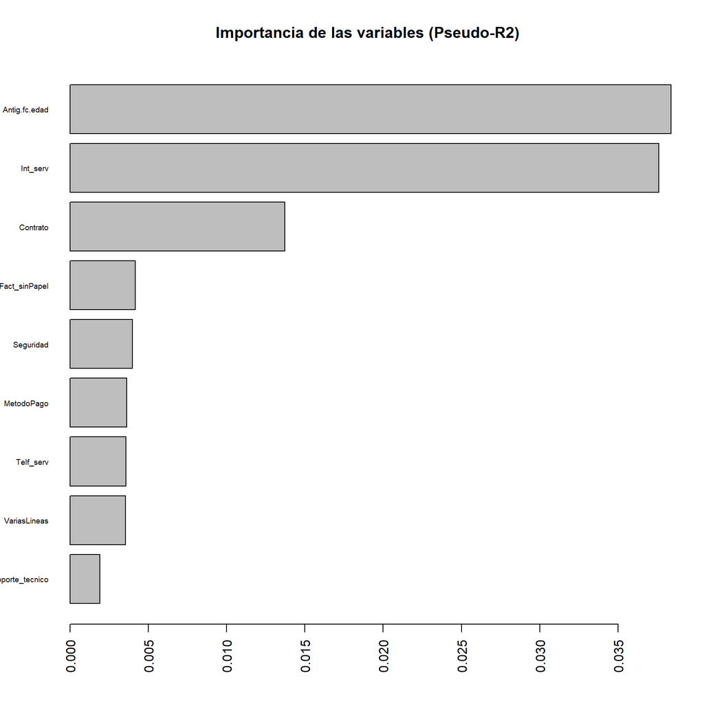

```r
impVariablesLog(modelo3,'varObjBin')
```

- Es un model muy estrellado pero ha bajado la pseudo R2 tanto en train como en test. Aún sigue siendo un modelo un poco grande, voy a seguir haciendo pruebas para ver si se puede mejorar.
- Realmente si comparamos el primer modelo con este podemos observar como bajando un punto en pseudo R2 tenemos un modelo con menos de la mitad de variables.

```r
modelo4<-glm(varObjBin~Int_serv+Antig.fc.edad+Contrato+Seguridad+Fact_sinPapel,
             data=data_train,family=binomial)
summary(modelo4)
```

```
##
## Call:
## glm(formula = varObjBin ~ Int_serv + Antig.fc.edad + Contrato +
##     Seguridad + Fact_sinPapel, family = binomial, data = data_train)
##
## Deviance Residuals:
##     Min       1Q   Median       3Q      Max
## -1.6691  -0.6847  -0.3143   0.7556   3.0801
##
## Coefficients:
##                      Estimate Std. Error z value Pr(>|z|)
## (Intercept)         -0.408717   0.094349  -4.332 1.48e-05 ***
## Int_servFiber optic  1.080443   0.087942  12.286  < 2e-16 ***
## Int_servNo          -0.889421   0.133926  -6.641 3.11e-11 ***
## Antig.fc.edad       -0.032998   0.002269 -14.540  < 2e-16 ***
## ContratoOne year    -0.767804   0.116869  -6.570 5.04e-11 ***
## ContratoTwo year    -1.448078   0.171844  -8.427  < 2e-16 ***
## SeguridadYes        -0.568188   0.098566  -5.765 8.19e-09 ***
## Fact_sinPapelYes     0.468680   0.084783   5.528 3.24e-08 ***
## ---
## Signif. codes:  0 '***' 0.001 '**' 0.01 '*' 0.05 '.' 0.1 ' ' 1
##
## (Dispersion parameter for binomial family taken to be 1)
##
##     Null deviance: 5882.3  on 5082  degrees of freedom
## Residual deviance: 4337.3  on 5075  degrees of freedom
## AIC: 4353.3
##
## Number of Fisher Scoring iterations: 6
```

```r
pseudoR2(modelo4,data_train,"varObjBin")
```

```
## [1] 0.2626548
```

```r
pseudoR2(modelo4,data_test,"varObjBin")
```

```
## [1] 0.2406296
```

```r
modelo4$rank
```

```
## [1] 8
```

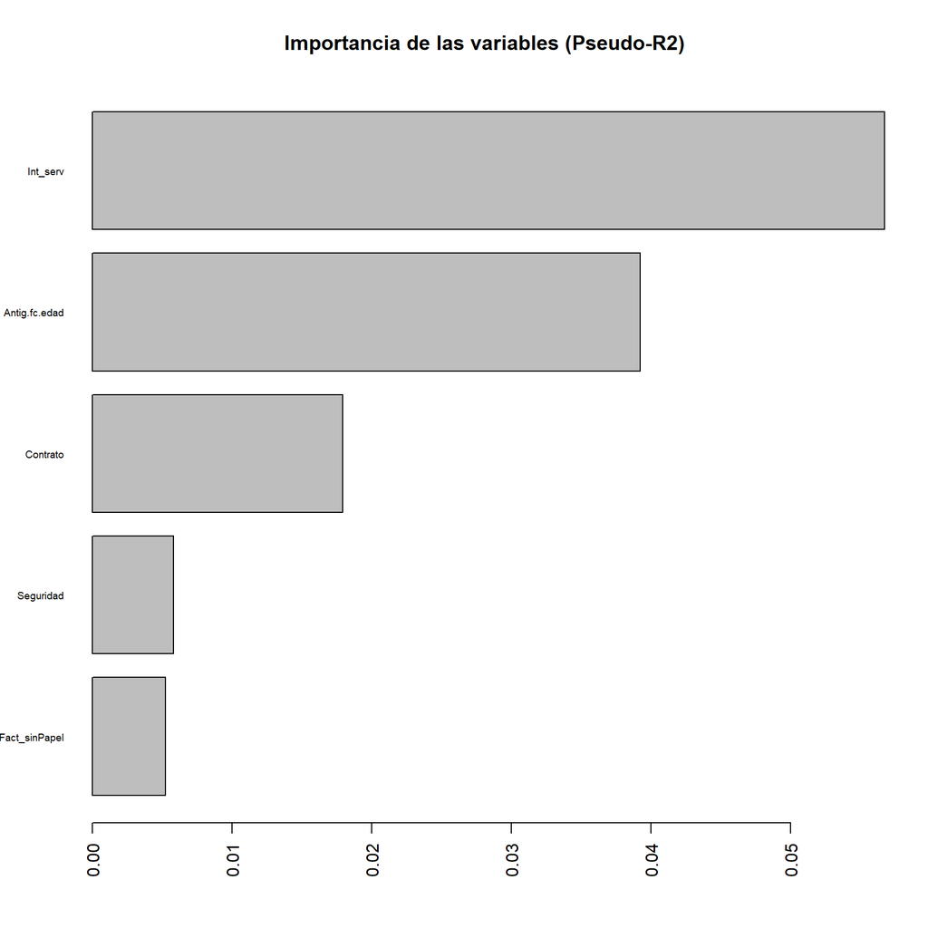

```r
impVariablesLog(modelo4,'varObjBin')
```

- Ha bajado un punto más la pseudo R2 en test y train.

```r
modelo5<-glm(varObjBin~Int_serv+Antig.fc.edad+Contrato+Seguridad,
             data=data_train,family=binomial)
summary(modelo5)
```

```
##
## Call:
## glm(formula = varObjBin ~ Int_serv + Antig.fc.edad + Contrato +
##     Seguridad, family = binomial, data = data_train)
##
## Deviance Residuals:
##     Min       1Q   Median       3Q      Max
## -1.6190  -0.7073  -0.3201   0.7928   3.0124
##
## Coefficients:
##                      Estimate Std. Error z value Pr(>|z|)
## (Intercept)         -0.126976   0.078465  -1.618    0.106
## Int_servFiber optic  1.155593   0.086812  13.311  < 2e-16 ***
## Int_servNo          -1.002018   0.132037  -7.589 3.23e-14 ***
## Antig.fc.edad       -0.032262   0.002257 -14.295  < 2e-16 ***
## ContratoOne year    -0.792292   0.116412  -6.806 1.00e-11 ***
## ContratoTwo year    -1.494141   0.171157  -8.730  < 2e-16 ***
## SeguridadYes        -0.594890   0.098127  -6.062 1.34e-09 ***
## ---
## Signif. codes:  0 '***' 0.001 '**' 0.01 '*' 0.05 '.' 0.1 ' ' 1
##
## (Dispersion parameter for binomial family taken to be 1)
##
##     Null deviance: 5882.3  on 5082  degrees of freedom
## Residual deviance: 4368.2  on 5076  degrees of freedom
## AIC: 4382.2
##
## Number of Fisher Scoring iterations: 6
```

```r
pseudoR2(modelo5,data_train,"varObjBin")
```

```
## [1] 0.2574024
```

```r
pseudoR2(modelo5,data_test,"varObjBin")
```

```
## [1] 0.2336806
```

```r
modelo5$rank
```

```
## [1] 7
```

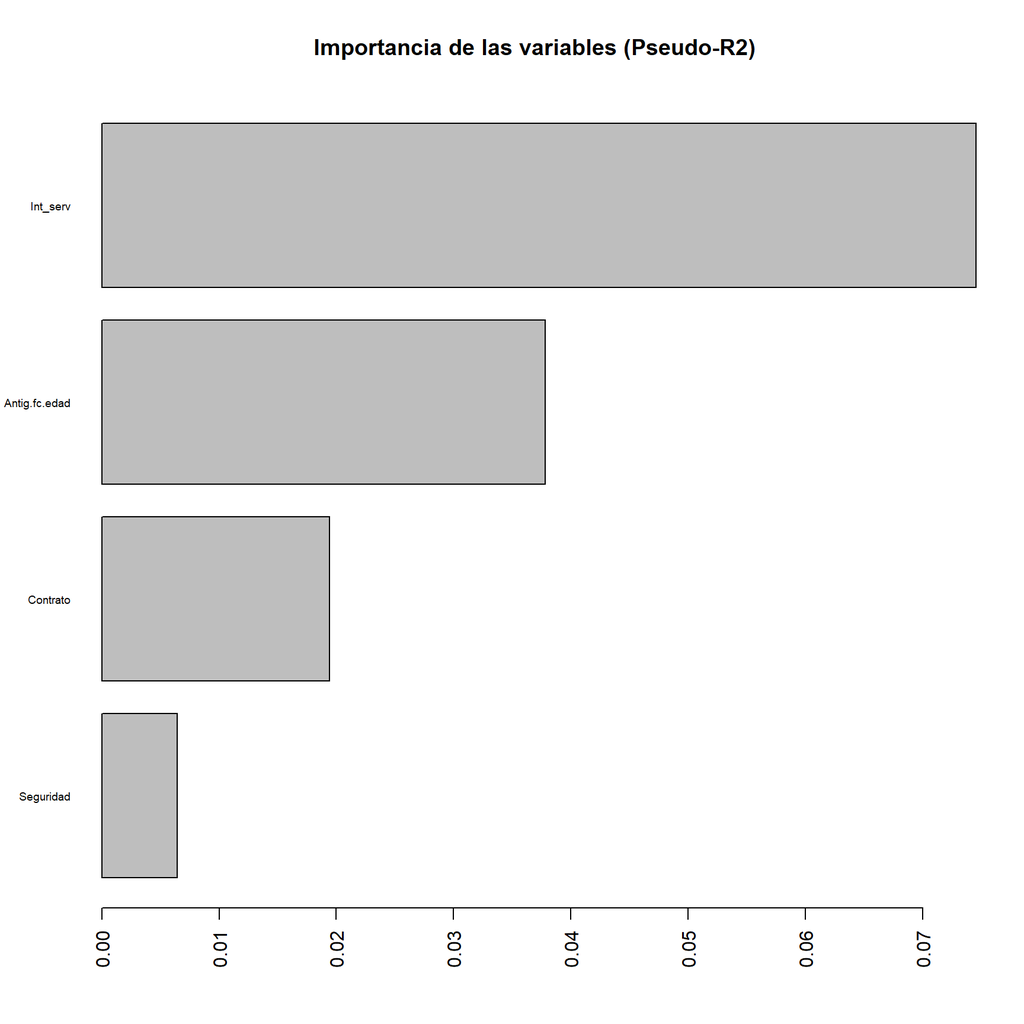

```r
impVariablesLog(modelo5,'varObjBin')
```

- Podemos ver un modelo muy senzillo pero con muchas estrellas. La pseudo R2 sigue bajando pero cada vez hay menos variables, en concreto ahora hay 7 en el análisis.

```r
modelo6<-glm(varObjBin~Int_serv+Antig.fc.edad+Contrato,
             data=data_train,family=binomial)
summary(modelo6)
```

```
##
## Call:
## glm(formula = varObjBin ~ Int_serv + Antig.fc.edad + Contrato,
##     family = binomial, data = data_train)
##
## Deviance Residuals:
##     Min       1Q   Median       3Q      Max
## -1.5960  -0.7120  -0.3188   0.8103   3.0705
##
## Coefficients:
##                      Estimate Std. Error z value Pr(>|z|)
## (Intercept)         -0.254674   0.075514  -3.373 0.000745 ***
## Int_servFiber optic  1.234560   0.085453  14.447  < 2e-16 ***
## Int_servNo          -0.829715   0.129433  -6.410 1.45e-10 ***
## Antig.fc.edad       -0.034607   0.002223 -15.566  < 2e-16 ***
## ContratoOne year    -0.846621   0.115527  -7.328 2.33e-13 ***
## ContratoTwo year    -1.578648   0.170057  -9.283  < 2e-16 ***
## ---
## Signif. codes:  0 '***' 0.001 '**' 0.01 '*' 0.05 '.' 0.1 ' ' 1
##
## (Dispersion parameter for binomial family taken to be 1)
##
##     Null deviance: 5882.3  on 5082  degrees of freedom
## Residual deviance: 4406.0  on 5077  degrees of freedom
## AIC: 4418
##
## Number of Fisher Scoring iterations: 6
```

```r
pseudoR2(modelo6,data_train,"varObjBin")
```

```
## [1] 0.250973
```

```r
pseudoR2(modelo6,data_test,"varObjBin")
```

```
## [1] 0.2319394
```

```r
modelo6$rank
```

```
## [1] 6
```

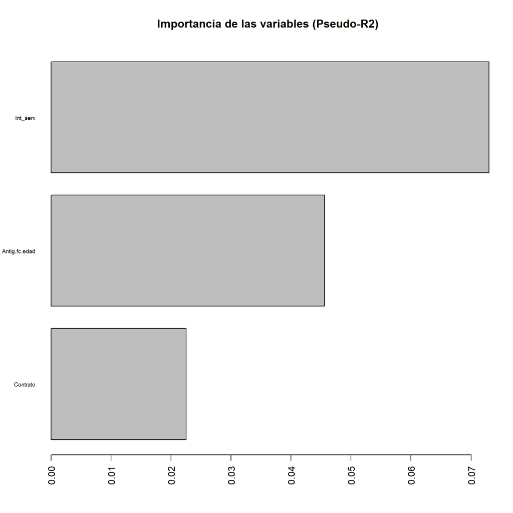

```r
impVariablesLog(modelo6,'varObjBin')
```

## 5) Modelado por selección de variables (clásica, aleatoria, Lasso..)

> He intentado de todas las formas pero me salen la Pseudo R2 con un resultado NaN. Me sabe mal pero he decidido excluir de la tarea este apartado ya que no sale como tiene que ser y los resultados de los modelos manuales salen cómo la media de la clase.

## 6) Comparación de modelos por validación cruzada repetida

```r
auxVarObj<-todo$varObjBin
todo$varObjBin<-make.names(todo$varObjBin)
```

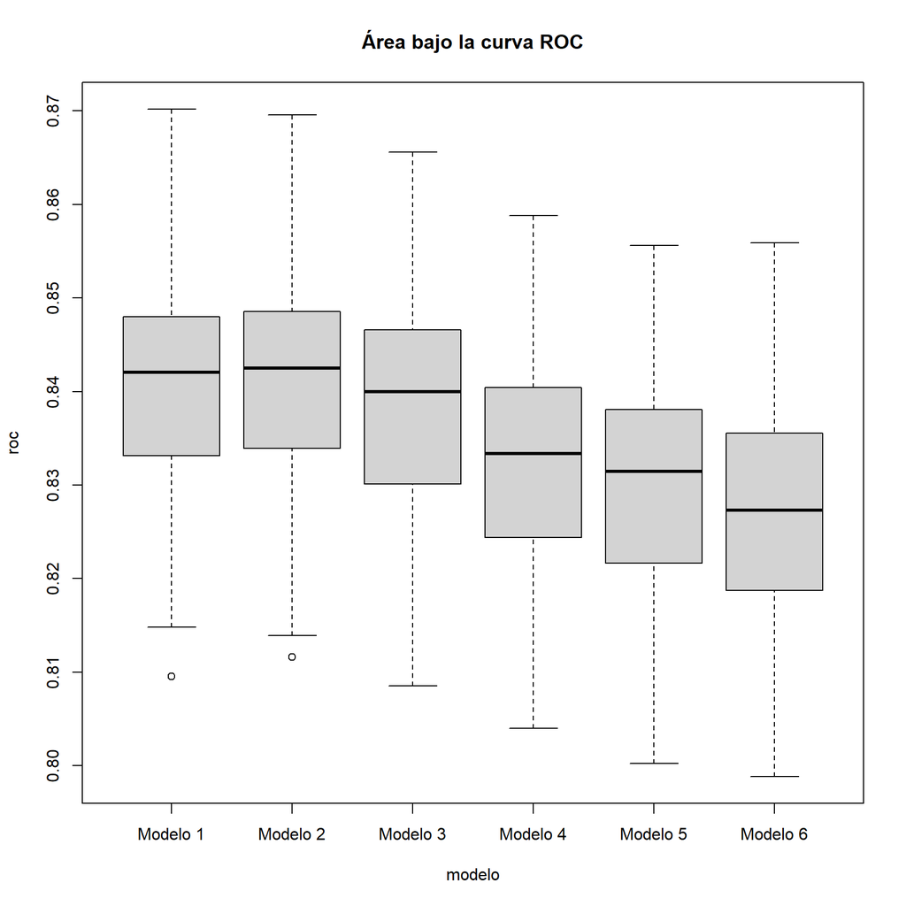

```r
total<-c()
modelos<-sapply(list(modeloInicial,modelo2,modelo3,modelo4,modelo5,modelo6),formula)
for (i in 1:length(modelos)){
  set.seed(1712)
  vcr<-train(as.formula(modelos[[i]]), data = todo,
             method = "glm", family="binomial",metric = "ROC",
             trControl = trainControl(method="repeatedcv", number=5, repeats=20,
                                      summaryFunction=twoClassSummary,
                                      classProbs=TRUE,returnResamp="all")
  )
  total<-rbind(total,data.frame(roc=vcr$resample[,1],modelo=rep(paste("Modelo",i),
                                                                nrow(vcr$resample))))
}

boxplot(roc~modelo,data=total,main="Área bajo la curva ROC")
```

- El boxplot muestra el sesgo-varianza de las estimaciones por validación cruzada para todos nuestros modelos.

En general todos son modelos son similares ya que tienen un valor de ROC en torno a 0.83 y 0,84, lo que indica una capacidad de clasificación buena. Las diferencias entre ellos son muy sutiles.

```r
aggregate(roc~modelo, data = total, mean)
```

```
##     modelo       roc
## 1 Modelo 1 0.8411063
## 2 Modelo 2 0.8417211
## 3 Modelo 3 0.8390896
## 4 Modelo 4 0.8331304
## 5 Modelo 5 0.8306038
## 6 Modelo 6 0.8277421
```

```r
aggregate(roc~modelo, data = total, sd)
```

```
##     modelo        roc
## 1 Modelo 1 0.01131317
## 2 Modelo 2 0.01126294
## 3 Modelo 3 0.01168564
## 4 Modelo 4 0.01143728
## 5 Modelo 5 0.01148316
## 6 Modelo 6 0.01159142
```

```r
modeloInicial$rank
```

```
## [1] 24
```

```r
modelo2$rank
```

```
## [1] 16
```

```r
modelo3$rank
```

```
## [1] 12
```

```r
modelo4$rank
```

```
## [1] 8
```

```r
modelo5$rank
```

```
## [1] 7
```

```r
modelo6$rank
```

```
## [1] 6
```